# Project Deliverable

Abraao Antonio, Claire Dardinski, Dan Skinner, Ivy Zhou

3/27/23

# **Executive Summary**

In this project, Team C assessed VIP’s business problem and designed an analysis around three objectives that provides insights into trends/patterns specific to customer types and packages, recommended applications to VIP’s business, and potential topics and techniques for further analyses.

The business problem was defined by VIP’s database stores information on all customer transactions, and their need to understand the behaviors and segmentations of their customers in order to improve their customer share and marketing strategies. From this business problem, three objectives were identified as:

- **Objective 1**: Identify patterns and/or trends in first-time and repeat purchases
- **Objective 2**: Determine whether the sale of one (or more) product(s) impact(s) the sale of other products
- **Objective 3**: Understand the life cycle behaviors of first-time and repeat customers

With these objectives, the team focused on analyzing sales data from VIP to gain insights into first-time and repeat purchases, the interplay between product sales, and the life cycle behaviors of these customers. To ensure the accuracy and reliability of the results, the team implemented a robust data cleaning and preparation process that involved preserving relevant data, handling missing values, condensing unique ones, and removing problematic or faulty data.

The project’s key findings identify similarities and differences in the monthly transactions by customer type, the topmost packages and package combinations for each customer type, and the distribution of time between purchases for those topmost packages.

To help VIP improve their customer share and marketing strategies, the team recommends changes and new ideas to the company’s strategies on discounts and marketing specific to each customer type. In addition, the team discusses limitations to our analysis as well as next steps for addressing those limitations and drilling into some of our more complex insights.

# **Data Preparation**

The data cleaning section is a crucial component of any data analysis project. The quality of the data used for analysis significantly impacts the accuracy and reliability of the results. Therefore, it is essential to ensure that the data is consistent, complete, and error-free. This section describes the data cleaning process, which involves four primary areas, including preserving relevant data, handling missing values, condensing unique values, and removing problematic or faulty data. By following these steps, we aim to create a clean and robust dataset that builds a solid foundation for future analysis.

1. **Preserve the data between 10/01/2020 to 01/01/2023:** In the follow-up interview with the clients, the team learned that all transactions predating October 1st, 2020, come from the old systems. Since the package identifications of old transactions did not translate to the new system, all old transactions are classified into only two packages: History and Shop. Due to the time constraint, the team assesses the project’s scope and determines to remove all transactions predating October 1, 2020, from our analysis.
2. **Handling missing values:** The source dataset contained a significant number of missing values, which required multiple processes to either impute or remove the affected entries. To address this issue, a lookup table was created outside the original database, which enabled us to impute all missing town and state values and exclude wholesale store 30. The details of the cleaning steps are outlined in the following code block sections for reference purposes.
3. **Condensed unique package values:** This project’s main focus is the package information and the original dataset contains over 328 different package names. The team member simplified the 328 unique Package Name values to 78 package focus areas to condense the package name information for more precise analysis. Additionally, after considering the needs of the clients, the team removed specific package entries, including “Shop” and “Standard Service.”
4. **Omit problematic and faulty data:** Several problematic transactions were excluded from the final clean dataset, such as wholesale customer purchase history and those affiliated with the consolidated set of cash customers.

# **Analysis**

## *Objective 1*

Objective 1 aims to identify patterns and/or trends in first-time and repeat purchases. To start, we choose to analyze the count of transactions of first-time and repeat customers across the years. More specifically, we consider the breakdown of transactions by our two customer types: first-time and repeat customers. Recall from our data preparation that our analysis only considers data that was transferred from VIP Tires’ previous data management system to their newer one. Therefore, the data presented in all figures and analyses will represent transactions recorded between October 1, 2020 and December 31, 2022.

### Figure 1

In Figure 1, the comparison of bar heights and compositions suggest that:

- From 2021 to 2022, the total number of customer transactions stayed relatively flat, increasing only 2%.
- In 2021 and 2022, roughly 75% of transactions were made by repeat customers.
- There was 5.7% growth in First-time vs 0.7% growth in Repeat Customer Transactions

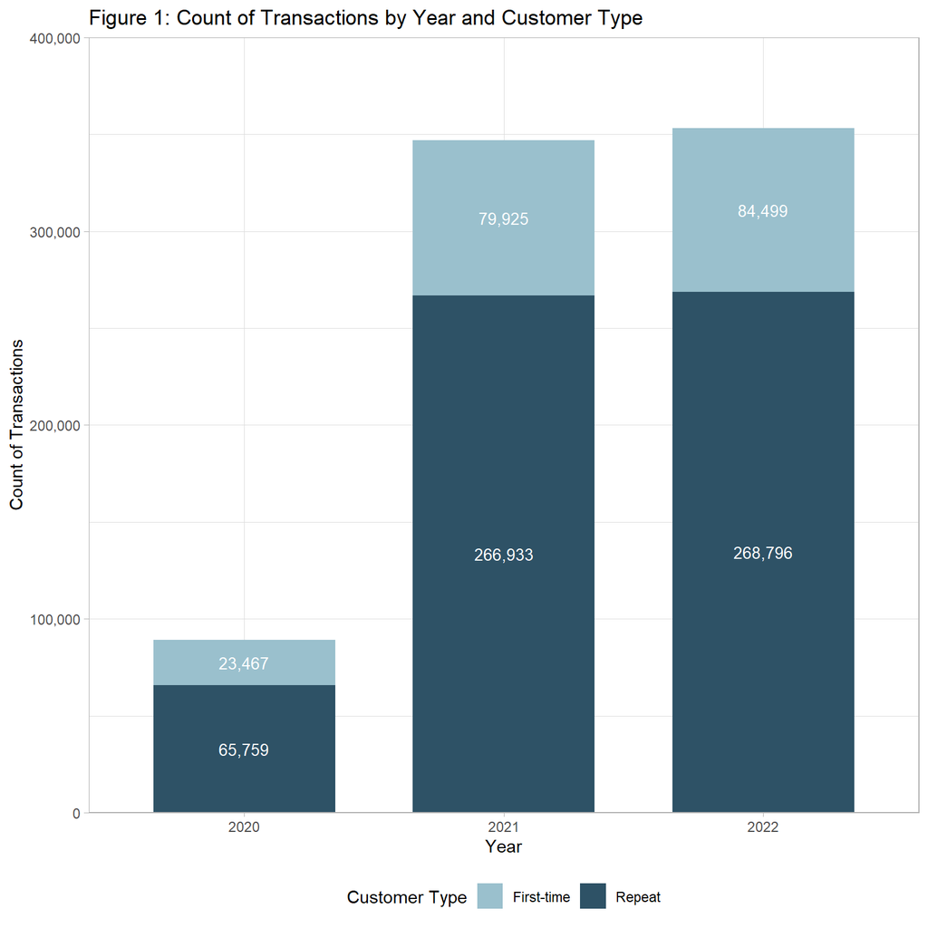

*How do the opening of new stores since 2020 (65-72) impact the number of transactions by year and by customer type?*

### Figure 2

Figure 2 mainly presents the counts of transactions based on existing stores and new stores over the studied years. The new stores (store number 65-72) are those stores which just started operating since 2020. This is the information from the clients based on the store birthday information that was given as supplement material. Figure 2 answers the Question: How do the opening of new stores since 2020 (65-72) impact the number of transactions by year and by customer type? As complete package data is only available from October 2020, year-over-year comparison can only be made between 2021 and 2022; From Figures 2, we learn:

- The count and breakdown of transactions by customers at existing stores was stable, even declining, from 2021 to 2022.
- Of those transactions made at existing stores, 23% were made by new customers and 77% were made by repeat customers.
- In 2021 and 2022, roughly 6% of transactions were made at new stores (and growing).
- Of those transactions made at new stores, 33% were made by new customers and 67% were made by repeat customers.

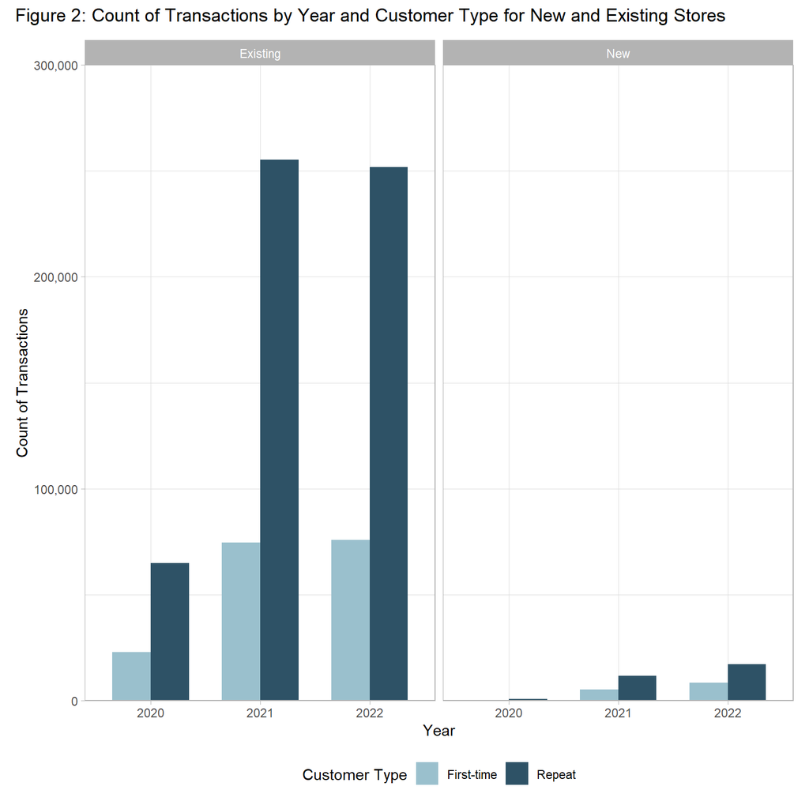

### Figure 3

Figure 3 introduces the count of transactions by month which provides deeper insight, and helps answer the question:

*across all years, how do the count and breakdown of transactions vary by month and customer type?*

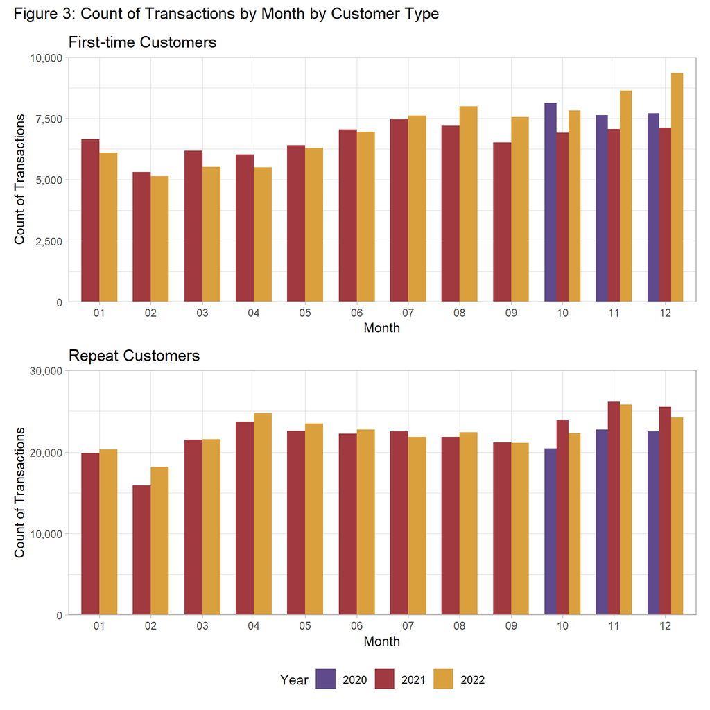

### Figure 4

The team selected 3 stores here to see if there are differences in trends/patterns at the store level:

The initial conclusion of the team is that: * there are seasonal differences across stores. * Discussions of whether these differences are meaningful requires further examination at the PackageFocus level.

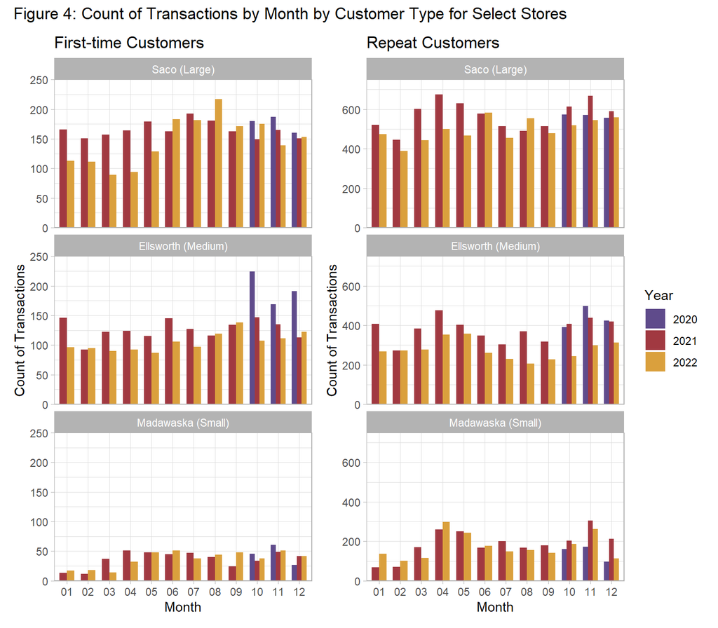

### Figure 5

To understand the drivers of transactions for repeat and first-time customers, we chose to focus on annual sales for each of the top 10 packages sold to each customer type.

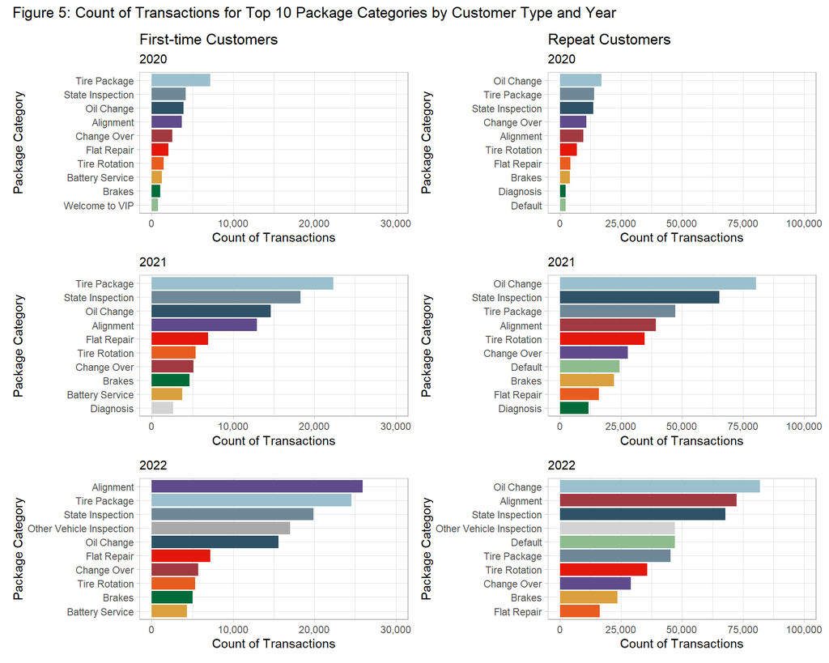

From Figure 5, we learn:

- For first-time customers, Tire Package, State Inspection, and Alignment packages were within the top 4 packages sold across all years. From 2021 to 2022, the total number of packages sold were relatively unchanged or increased slightly for all packages, except for:
  - Alignment and Other Vehicle Inspection, with Other Vehicle Inspection making its way into the top 10.
  - Diagnosis sales decreased and fell out of the top 10.
- For repeat customers, Oil Change was the top package sold across all years. The State Inspection package was also within the top three across all years. From 2021 to 2022, the total number of packages sold were relatively unchanged or decreased slightly for all packages, except for:
  - Alignment, Default, and Other Vehicle Inspection increased, with Other Vehicle Inspection making its way into the top 10.
  - Diagnosis sales decreased and fell out of the top 10.

Note: first-time and repeat customers both increased sales for Alignment and Other Vehicle Inspection packages and decreased sales for the Diagnosis package

## *Objective 2*

Objective (2) is to determine whether the sale of one (or more) product(s) impact the sale of other products.

### Figure 6

Key Takeaways:

Visualizing the top combinations of PackagesFocus purchased by first-time and repeat customers can be very valuable for marketing teams in creating effective sales packages and promotions. By analyzing the data and identifying the most popular combinations the marketing team can:

- Increase overall sales and customer retention.
- Tailor their advertisements to incentivize customers to purchase them.
- Can be used to inform product development decisions, such as introducing new packages that combine popular services or modifying existing packages to better align with customer preferences.

### Figure 7

After generating some insights on combinations of two packages, we became curious about combinations of three packages. For each type of customer, we focused only on the combinations of their top 4 packages purchased from October 2020 through December 2022. For both first-time and repeat customers, these are the Tire Package, State Inspection, Oil Change, and Alignment.

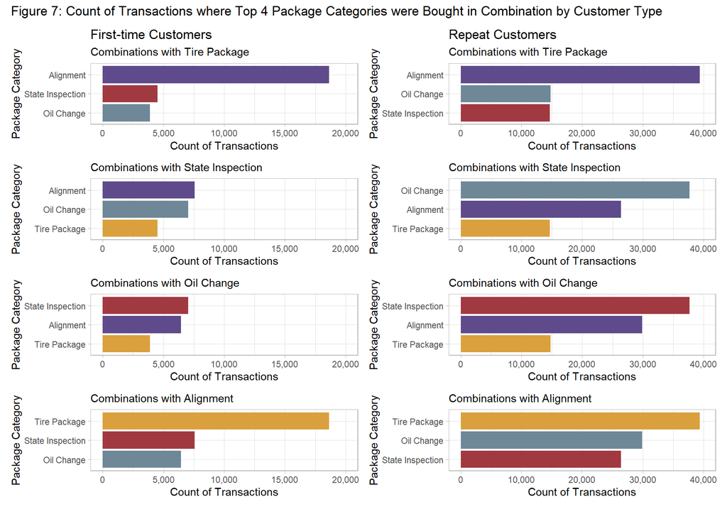

Figure 7 shows how many times each customer type combined one of the top 4 packages with the other three packages.

- Across both customer types, the count of transactions across all years are highest Tire Package, State Inspection, Oil Change, and Alignment. Alignment is the package category most frequently combined with the other top 3 package categories. Alignment is most frequently combined with Tire Package, and Tire Package is most frequently combined with Alignment.
- For first-time customers, combinations with State Inspection and Oil Change are less frequent and more balanced.
- For repeat customers, State Inspection and Oil Change are frequently combined with each other and rarely combined with Tire Package.

While the insights generated from Figure 7 are meaningful, their limitation to only four package categories is restrictive. For more comprehensive and quantitative insights, we turn to a Market Basket Analysis.

### Market Basket Analysis

#### Part 1: Market Basket Analysis for All Customers

Market basket analysis can be performed for various purposes, and one of them is to understand the differences in customer purchase behavior in purchasing different packages. This study will perform market basket analysis to discover the correlation between the customer behavior and package purchase data. By examining the products that customers tend to purchase together, the clients would be able to identify patterns and associations that may not be immediately apparent from looking at individual transactions or customer profiles. Moreover, market basket analysis could increase the likelihood of repeat purchases and boost the revenue by suggesting related products to customer based on the previous packages purchase information, or even develop strategy to sell packages as a combination. When performing the analysis, the clients expressed the need to remove “Shop”, “PM” and “Standard Service” legacy packages, so this market basket does not include the mentioned 3 packages.

In market basket analysis, there are typically three main steps: data preparation, package frequency analysis, and rule generation using the Apriori algorithm.

In the data preparation step, the transactional data is cleaned and transformed to fit the requirements of the arules library in R Studio. This involves removing unwanted package names and separating each transaction into individual baskets, where each basket represents all the packages purchased in a single transaction.

The next step is to analyze the frequency of each package in the data set. This is done by visualizing the frequency distribution using an absolute package frequency plot. This plot shows how often each package was purchased and can help identify which packages got the most attention in the customers purchase history.

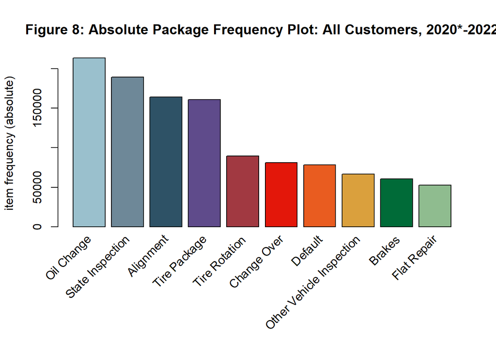

```
## Apriori
##
## Parameter specification:
##  confidence minval smax arem  aval originalSupport maxtime support minlen
##         0.8    0.1    1 none FALSE            TRUE       5   0.001      1
##  maxlen target  ext
##      10  rules TRUE
##
## Algorithmic control:
##  filter tree heap memopt load sort verbose
##     0.1 TRUE TRUE  FALSE TRUE    2    TRUE
##
## Absolute minimum support count: 780
##
## set item appearances ...[0 item(s)] done [0.00s].
## set transactions ...[75 item(s), 780606 transaction(s)] done [0.25s].
## sorting and recoding items ... [58 item(s)] done [0.01s].
## creating transaction tree ... done [0.35s].
## checking subsets of size 1 2 3 4 5 done [0.01s].
## writing ... [82 rule(s)] done [0.00s].
## creating S4 object  ... done [0.05s].
```

```r
knitr::opts_current$set(eval = TRUE)
#Item frequency plot
package_colors_10 <- c("#9AC0CD","#6E8898FF","#2E5266FF","#5F4B8BFF","#A13941FF","#E3170AFF","#E95C20FF","#DAA03DFF","#006B38FF","#8FBC8F")
itemFrequencyPlot(tr,topN=10,type="absolute",col=package_colors_10, main="Figure 8: Absolute Package Frequency Plot: All Customers, 2020*-2022")
```

```r
knitr::opts_current$set(eval = TRUE)
inspect(association.rules[1:10])
```

```
##      lhs                            rhs                            support confidence    coverage      lift count
## [1]  {Alignment,
##       Donation,
##       State Inspection}          => {Other Vehicle Inspection} 0.001337422  0.9657724 0.001384822 11.319976  1044
## [2]  {Alignment,
##       Donation,
##       Oil Change}                => {Other Vehicle Inspection} 0.001396351  0.9628975 0.001450155 11.286279  1090
## [3]  {Tie-Rod Replace,
##       Tire Package}              => {Alignment}                0.002340489  0.9610731 0.002435287  4.578920  1827
## [4]  {Other Vehicle Inspection,
##       State Inspection,
##       Tire Package}              => {Alignment}                0.001884433  0.9608099 0.001961297  4.577666  1471
## [5]  {Oil Change,
##       Tire Studding}             => {Tire Package}             0.001028688  0.9570918 0.001074806  4.648558   803
## [6]  {Alignment,
##       Tire Adjustment}           => {Tire Package}             0.001339985  0.9561243 0.001401475  4.643859  1046
## [7]  {Alignment,
##       Donation}                  => {Other Vehicle Inspection} 0.004766809  0.9533692 0.004999962 11.174596  3721
## [8]  {Alignment,
##       Tire Studding}             => {Tire Package}             0.002855474  0.9468989 0.003015606  4.599052  2229
## [9]  {State Inspection,
##       Tie-Rod Replace}           => {Alignment}                0.002997671  0.9450727 0.003171895  4.502688  2340
## [10] {Brakes,
##       Tie-Rod Replace}           => {Alignment}                0.001939519  0.9427148 0.002057376  4.491454  1514
```

Above figure introduces the market basket result on all the transaction data that discuss the combination of different packages. This inspection is ranked in descending order by the confidence level of the packages information. From the figure, we learn that:

- Around 96.6 percent of the customers who purchased the package combination of {“Alignment” , “Donation” , and “State Inspection”} also purchased “Other Vehicle Inspection”.
- Around 96.3 percent of the customers who purchased the package combination of {“Alignment” , “Donation” , and “Oil Change”} also purchased “Other Vehicle Inspection”.
- “Alignment”, “Tire package” and “Other Vehicle Inspection” packages are very popular side packages for the customers to purchase. VIP Tires could consider developing a package combination market strategy, or also recommend these three packages to the customers who have purchased corresponding packages. For example, the store would recommend the car owner to get an alignment service while purchasing a “Tire Package”.

```
## Apriori
##
## Parameter specification:
##  confidence minval smax arem  aval originalSupport maxtime support minlen
##         0.8    0.1    1 none FALSE            TRUE       5   0.001      1
##  maxlen target  ext
##      10  rules TRUE
##
## Algorithmic control:
##  filter tree heap memopt load sort verbose
##     0.1 TRUE TRUE  FALSE TRUE    2    TRUE
##
## Absolute minimum support count: 780
##
## set item appearances ...[0 item(s)] done [0.00s].
## set transactions ...[75 item(s), 780606 transaction(s)] done [0.12s].
## sorting and recoding items ... [58 item(s)] done [0.02s].
## creating transaction tree ... done [0.33s].
## checking subsets of size 1 2 3 4 5 done [0.01s].
## writing ... [82 rule(s)] done [0.00s].
## creating S4 object  ... done [0.04s].
```

```
## set of 82 rules
##
## rule length distribution (lhs + rhs):sizes
##  2  3  4  5
##  5 44 31  2
##
##    Min. 1st Qu.  Median    Mean 3rd Qu.    Max.
##   2.000   3.000   3.000   3.366   4.000   5.000
##
## summary of quality measures:
##     support           confidence        coverage             lift
##  Min.   :0.001022   Min.   :0.8000   Min.   :0.001075   Min.   : 2.983
##  1st Qu.:0.001355   1st Qu.:0.8477   1st Qu.:0.001551   1st Qu.: 3.979
##  Median :0.001761   Median :0.8844   Median :0.001989   Median : 4.179
##  Mean   :0.004199   Mean   :0.8866   Mean   :0.004803   Mean   : 4.405
##  3rd Qu.:0.003930   3rd Qu.:0.9310   3rd Qu.:0.004479   3rd Qu.: 4.425
##  Max.   :0.071537   Max.   :0.9658   Max.   :0.085316   Max.   :11.320
##      count
##  Min.   :  798
##  1st Qu.: 1058
##  Median : 1374
##  Mean   : 3277
##  3rd Qu.: 3068
##  Max.   :55842
##
## mining info:
##  data ntransactions support confidence
##    tr        780606   0.001        0.8
##                                                            call
##  apriori(data = tr, parameter = list(supp = 0.001, conf = 0.8))
```

```r
knitr::opts_current$set(eval = TRUE)
inspect(rules[1:20])
```

```
##      lhs                            rhs                            support confidence    coverage      lift count
## [1]  {Alignment,
##       Donation,
##       State Inspection}          => {Other Vehicle Inspection} 0.001337422  0.9657724 0.001384822 11.319976  1044
## [2]  {Alignment,
##       Donation,
##       Oil Change}                => {Other Vehicle Inspection} 0.001396351  0.9628975 0.001450155 11.286279  1090
## [3]  {Tie-Rod Replace,
##       Tire Package}              => {Alignment}                0.002340489  0.9610731 0.002435287  4.578920  1827
## [4]  {Other Vehicle Inspection,
##       State Inspection,
##       Tire Package}              => {Alignment}                0.001884433  0.9608099 0.001961297  4.577666  1471
## [5]  {Oil Change,
##       Tire Studding}             => {Tire Package}             0.001028688  0.9570918 0.001074806  4.648558   803
## [6]  {Alignment,
##       Tire Adjustment}           => {Tire Package}             0.001339985  0.9561243 0.001401475  4.643859  1046
## [7]  {Alignment,
##       Donation}                  => {Other Vehicle Inspection} 0.004766809  0.9533692 0.004999962 11.174596  3721
## [8]  {Alignment,
##       Tire Studding}             => {Tire Package}             0.002855474  0.9468989 0.003015606  4.599052  2229
## [9]  {State Inspection,
##       Tie-Rod Replace}           => {Alignment}                0.002997671  0.9450727 0.003171895  4.502688  2340
## [10] {Brakes,
##       Tie-Rod Replace}           => {Alignment}                0.001939519  0.9427148 0.002057376  4.491454  1514
## [11] {Other Vehicle Inspection,
##       Tire Studding}             => {Tire Package}             0.001760171  0.9417409 0.001869061  4.573999  1374
## [12] {Oil Change,
##       Other Vehicle Inspection,
##       Tire Package}              => {Alignment}                0.002049690  0.9417304 0.002176514  4.486764  1600
## [13] {Alignment,
##       Other Vehicle Inspection,
##       Tire Studding}             => {Tire Package}             0.001646157  0.9413919 0.001748641  4.572304  1285
## [14] {Other Vehicle Inspection,
##       Tire Package,
##       TPMS}                      => {Alignment}                0.001316926  0.9405306 0.001400194  4.481048  1028
## [15] {Air Filter,
##       Default,
##       Tire Rotation}             => {Oil Change}               0.001451436  0.9386910 0.001546235  3.434873  1133
## [16] {Change Over,
##       Other Vehicle Inspection,
##       TPMS}                      => {Alignment}                0.001233657  0.9376826 0.001315645  4.467479   963
## [17] {Other Vehicle Inspection,
##       Tire Studding}             => {Alignment}                0.001748641  0.9355723 0.001869061  4.457425  1365
## [18] {Other Vehicle Inspection,
##       Tire Package,
##       Tire Studding}             => {Alignment}                0.001646157  0.9352256 0.001760171  4.455773  1285
## [19] {Cabin Filter,
##       Default,
##       Tire Rotation}             => {Oil Change}               0.001022283  0.9344262 0.001094022  3.419268   798
## [20] {Change Over,
##       Other Vehicle Inspection,
##       State Inspection}          => {Alignment}                0.001546235  0.9320463 0.001658968  4.440625  1207
```

[interactive chart not shown]

Above figure is the visualization of the market basket analysis result. The size and color of the vertices usually represent the interest strength. The arrows represent the direction of the packages relation. This figure could better indicates the importance of “Tire Package”, Alignment”, and “Other Vehicle Inspection”, since these three packages are in the center of the interest focus.

#### Part 2: Market Basket Analysis for first-time and repeat customers

The previous market basket analysis focused on understanding the purchasing patterns of all customers. The second part of this market basket analysis will mainly compare the purchasing behavior between first-time and repeat customers. By performing this comparison, VIP Tires could introduce package combos or service suggestions based on whether it is the customer’s first visit to the store. Moreover, this analysis would assist the market analysis team in developing strategies to convert first-time customers into potential long-term, loyal customers. Since every customer has a unique identification number, we are able to determine whether the customers are repeat customers by summing up the unique transaction amount.

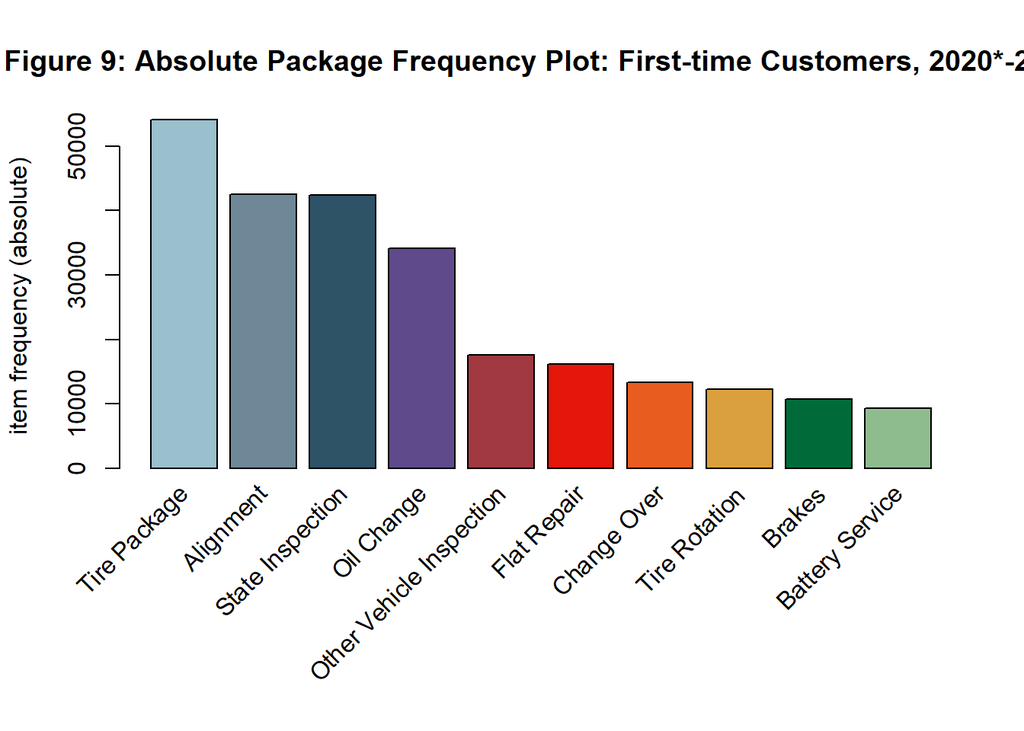

```
## Apriori
##
## Parameter specification:
##  confidence minval smax arem  aval originalSupport maxtime support minlen
##         0.8    0.1    1 none FALSE            TRUE       5   0.001      1
##  maxlen target  ext
##      10  rules TRUE
##
## Algorithmic control:
##  filter tree heap memopt load sort verbose
##     0.1 TRUE TRUE  FALSE TRUE    2    TRUE
##
## Absolute minimum support count: 185
##
## set item appearances ...[0 item(s)] done [0.00s].
## set transactions ...[75 item(s), 185929 transaction(s)] done [0.05s].
## sorting and recoding items ... [52 item(s)] done [0.00s].
## creating transaction tree ... done [0.04s].
## checking subsets of size 1 2 3 4 5 done [0.00s].
## writing ... [58 rule(s)] done [0.00s].
## creating S4 object  ... done [0.01s].
```

```r
knitr::opts_current$set(eval = TRUE)
package_colors_10 <- c("#9AC0CD","#6E8898FF","#2E5266FF","#5F4B8BFF","#A13941FF","#E3170AFF","#E95C20FF","#DAA03DFF","#006B38FF","#8FBC8F")
#Item frequency plot
itemFrequencyPlot(tr,topN=10,type="absolute",col=package_colors_10, main="Figure 9: Absolute Package Frequency Plot: First-time Customers, 2020*-2022")
```

```r
knitr::opts_current$set(eval = TRUE)
inspect(association.rules[1:10])
```

```
##      lhs                            rhs                            support confidence    coverage      lift count
## [1]  {Tie-Rod Replace,
##       Tire Package}              => {Alignment}                0.002393387  0.9866962 0.002425657  4.311526   445
## [2]  {Brakes,
##       Tie-Rod Replace}           => {Alignment}                0.001247788  0.9789030 0.001274680  4.277472   232
## [3]  {Oil Change,
##       Tie-Rod Replace}           => {Alignment}                0.001167112  0.9774775 0.001194004  4.271243   217
## [4]  {Other Vehicle Inspection,
##       State Inspection,
##       Tire Package}              => {Alignment}                0.002296576  0.9748858 0.002355738  4.259919   427
## [5]  {State Inspection,
##       Tie-Rod Replace}           => {Alignment}                0.002156737  0.9662651 0.002232035  4.222249   401
## [6]  {Alignment,
##       Donation,
##       State Inspection}          => {Other Vehicle Inspection} 0.001484438  0.9650350 0.001538222 10.190140   276
## [7]  {Tie-Rod Replace}           => {Alignment}                0.007061835  0.9647318 0.007319998  4.215549  1313
## [8]  {Control Arm,
##       Tire Package}              => {Alignment}                0.001172491  0.9603524 0.001220896  4.196413   218
## [9]  {Control Arm,
##       State Inspection}          => {Alignment}                0.001118707  0.9585253 0.001167112  4.188429   208
## [10] {Alignment,
##       Donation}                  => {Other Vehicle Inspection} 0.005211667  0.9584570 0.005437559 10.120681   969
```

[interactive chart not shown]

Part 3: Repeat Customers

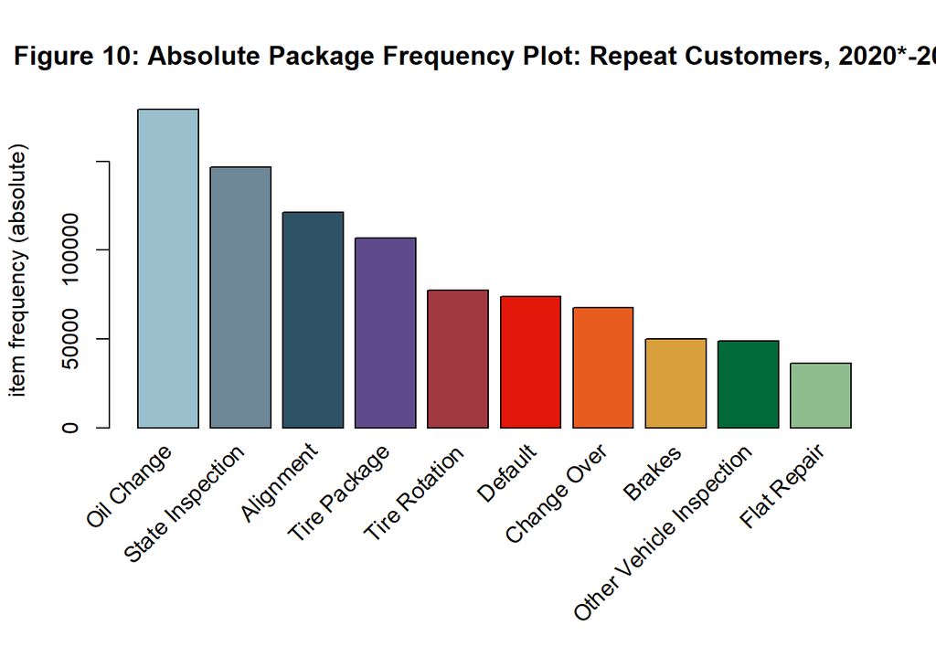

```r
knitr::opts_current$set(eval = TRUE)
package_colors_10 <- c("#9AC0CD","#6E8898FF","#2E5266FF","#5F4B8BFF","#A13941FF","#E3170AFF","#E95C20FF","#DAA03DFF","#006B38FF","#8FBC8F")
#Item frequency plot
itemFrequencyPlot(tr,topN=10,type="absolute",col=package_colors_10, main="Figure 10: Absolute Package Frequency Plot: Repeat Customers, 2020*-2022")
```

The figures for first-time customers show that the most popular package purchased from VIP Tires is the “Tire Package,” followed by “Alignment,” “State Inspection,” and “Oil change.” On the other hand, repeat customers are more likely to purchase the “Oil change,” “State Inspection,” and “Alignment” packages, with “Tire Package” being the fourth most frequent purchase. These frequency results are consistent with the analysis of all customers. This suggests that most first-time customers are more likely to come to the store to purchase tires, while repeat customers return for additional services provided by the company.

```r
knitr::opts_current$set(eval = TRUE)
inspect(association.rules[1:10])
```

```
##      lhs                            rhs                            support confidence    coverage      lift count
## [1]  {Other Vehicle Inspection,
##       Tie-Rod Replace}           => {Alignment}                0.001019039  0.9758454 0.001044263  4.784436   606
## [2]  {Alignment,
##       Donation,
##       State Inspection}          => {Other Vehicle Inspection} 0.001291455  0.9660377 0.001336858 11.726503   768
## [3]  {Alignment,
##       Donation,
##       Oil Change}                => {Other Vehicle Inspection} 0.001521832  0.9637913 0.001579006 11.699234   905
## [4]  {Oil Change,
##       Tire Studding}             => {Tire Package}             0.001145158  0.9605078 0.001192242  5.356724   681
## [5]  {Alignment,
##       Tire Adjustment}           => {Tire Package}             0.001652995  0.9552964 0.001730348  5.327660   983
## [6]  {Other Vehicle Inspection,
##       State Inspection,
##       Tire Package}              => {Alignment}                0.001755572  0.9551693 0.001837969  4.683064  1044
## [7]  {Tie-Rod Replace,
##       Tire Package}              => {Alignment}                0.002323947  0.9531034 0.002438294  4.672935  1382
## [8]  {Alignment,
##       Tire Studding}             => {Tire Package}             0.002739298  0.9526316 0.002875506  5.312799  1629
## [9]  {Alignment,
##       Donation}                  => {Other Vehicle Inspection} 0.004627714  0.9515906 0.004863136 11.551133  2752
## [10] {Alignment,
##       Change Over,
##       Donation}                  => {Other Vehicle Inspection} 0.001089665  0.9501466 0.001146839 11.533605   648
```

[interactive chart not shown]

## *Objective 3*

Ojective (3) is to understand the life cycle behaviors of first-time and repeat customers.

After studying the top absolute frequencies and rules in our Market Basket analysis, we want to understand how those results might depend on the typical duration for each package category.

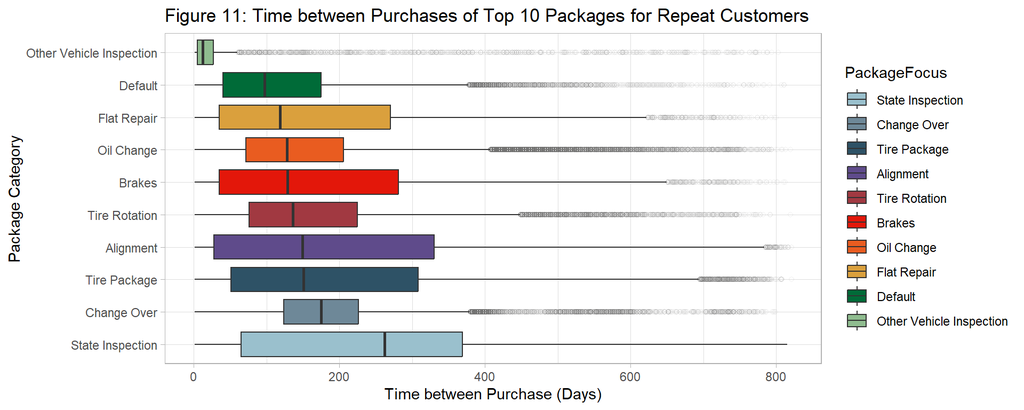

```r
knitr::opts_current$set(eval = TRUE)
package_colors_10 <- c("#9AC0CD","#6E8898FF","#2E5266FF","#5F4B8BFF","#A13941FF","#E3170AFF","#E95C20FF","#DAA03DFF","#006B38FF","#8FBC8F")

#calculate total lifetime and previous visits
visits <- df1 %>%
  filter(repeat_customer == "Yes") %>%
  filter(PackageFocus != "Shop") %>%
  filter(PackageFocus != "PM") %>%
  filter(PackageFocus != "Standard Service") %>%
  group_by(PackageFocus, CustomerId, Date) %>%
  tally(sort=FALSE) %>%
  rename(TotalPackagesPerVisit = n) %>%
  mutate(TotalPreviousVisits = row_number()-1) %>%
  mutate(TotalLifetimeVisits = max(TotalPreviousVisits)+1)

#total transactions by repeat customers for any package
total_trans <- length(df1$PackageFocus)

#reference to top 10 packages for repeat customers
top_10_packages_repeat_df <- visits %>%
  group_by(PackageFocus) %>%
  summarize(TotalPackages = n()) %>%
  arrange(desc(TotalPackages)) %>%
  slice(1:10)

top_10_packages_repeat <- unique(top_10_packages_repeat_df$PackageFocus)

#calculate days between visits for top 10 packages for repeat customers
days_between_visits <- visits %>%
  filter(PackageFocus %in% top_10_packages_repeat) %>%
  filter(TotalLifetimeVisits > 1) %>%
  mutate(DaysBetweenVisits =
           ifelse(TotalPreviousVisits == 0, "N/A",
                  Date - lag(Date)))

#remove the row with the first date (as that has N/A value for days between visits)
#and conver the days between visits column to integers
days_between_visits_excl_first_date <- days_between_visits %>%
  filter(DaysBetweenVisits != "N/A") %>%
  mutate(DaysBetweenVisits = as.integer(DaysBetweenVisits))

perc_of_total_trans <- days_between_visits_excl_first_date %>%
  group_by(PackageFocus) %>%
  summarize(Perc_Trans = round(n()/total_trans*100))


#calculate the median number of days between visits
median_days_between_visits <- days_between_visits_excl_first_date %>%
  group_by(PackageFocus) %>%
  summarize(median_duration = round(median(DaysBetweenVisits),1),
            total_repeats = sum(TotalPreviousVisits)) %>%
  arrange(desc(median_duration))

#create box plot of days between visits by package focus area
days_between_visits_excl_first_date$PackageFocus <- factor(days_between_visits_excl_first_date$PackageFocus, levels=median_days_between_visits$PackageFocus)
days_between_visits_excl_first_date %>%
  ggplot(aes(x = PackageFocus, y = DaysBetweenVisits, fill=PackageFocus)) +
  geom_boxplot(outlier.shape = 1,outlier.alpha = 0.1, outlier.color="#6E6E6DFF") +
  coord_flip() +
  labs(y = "Time between Purchase (Days)", x = "Package Category") +
  theme(legend.position = "none") +
  ggtitle("Figure 11: Time between Purchases of Top 10 Packages for Repeat Customers") +
  scale_fill_manual(values=package_colors_10) +
  theme_light()
```

# Key Findings and Recommendations

All of this analysis has led to some meaningful findings:

- Monthly transactions for first-time and repeat customers shared some lows (in February) and highs (in November-December), and complemented each other in the remaining months of the year. Relative to their 2021 transactions, first-time customers’ transactions worsened/improved in H1/H2 while repeat customer transactions did just the opposite.
- In terms of absolute frequency for all 2020-2022 transactions, first-time and repeat customers shared the same top 4 package categories: Tire Package, State Inspection, Oil Change, and Alignment. However, the Tire Package led for first-time customers while the three services led for repeat customers. These top 4 package categories for repeat customers are rather surprising given the median duration between repeat purchases of all top 10 package categories.
- In terms of combined packages, first-time customers most frequently combined Alignment with Tire-Rod Replace and other packages. Repeat customers most frequently combined service-related packages with Alignment and/or Other Vehicle Inspection packages.

With these findings, we’d like to propose a few recommendations to VIP:

- For first-time customers, offering a discount on their next service if they purchase a Tire Package, or a discount on their purchase if they combine Alignment and Tire-Rod Replace packages
- For repeat customers, considering the timing and package of their last purchase and the average duration between visits for that package; if timing of multiple packages align, offer discounts for a combination of those packages
- Learning from the promotions and advertisements received by first-time and repeat customers in the months where transactions counts were especially high or low
- Brainstorming special discounts and/or events to increase both first time and repeat customers in February
- Evaluating the pricing and quality of service provided for top absolute and combination packages, especially those with surprisingly shorter/longer median durations between repeat purchases
- Investing in further analysis of customer transactions

# Next Steps

Next steps should consider the following:

- The tires replacement cycle is generally 30,000 to 60,000 miles; meanwhile, brakes should be inspected every 20,000 to 30,000 miles or 1-2 years, with brake pads lasting 40,000 to 70,000 miles. The United States Department of Transportation Federal Highway Administration reports that the average driver traveled 12,724 miles in 2020, down from 14,263 average annual miles in 2019; therefore, a data range of 3-6 years would be necessary to examine the repurchase habits of a single customer with a single car. 2.25 years of data needed to be expanded.
- Because of this knowledge, one of our team members focused on assigning PackageFocus from History based on SKU, Descriptions and the KPI data table previously provided and has recently completed a “key table” which will be provided to VIP to support future efforts to extend the start of the data set from Q4 2020 back to Q4 2017 (or earlier). While time constraints prevented the team from integrating this advance into our analysis, VIP may find the information useful in taking the analysis further.
- Given the limited loyalty and vehicle data and the only customer demographic data being zip code, the team considered how to utilize the available data. Loyalty Program, Vehicle, Customer Zip Code and Store geospatial data has also been provided for use in any subsequent regression and categorization analyses. Proposals included considering the distance between VIP’s stores and population centers and the vehicle, economic and competition demographics of customer zip codes as factors in regression and classification analysis. Search, social media and credit-card processing-based analytics data may provide other interesting external datasets to supplement internal data.

To further our exploration of Objective (1), VIP might consider other measures and graphs that would help their analysts understand the life cycle behaviors of first-time and repeat customers, such as:

- Categorize customers into bins according to Total Lifetime Visits, and analyze seasonality and volume of monthly sales separately.
- Investigate the impact of new store openings on the lifecycle and behaviors for new customers
- Conduct a deeper dive into Q4 sales for new customers.

To further VIP’s exploration of Objective (2), they might consider expanding on the team’s focus on:

- Examine specific packages focus areas, such as the ones that are sold the most, sold the least, or sold differently across repeat and first-time customers.
- Regression/Classification comparing Tire Package-purchasing Customers vs. non-Tire Customers.
- Assess seasonality of sales by month and/or quarter by key package focus areas.
- Compare packages sold by store location to look at local market differences.

To further explore Objective (3), VIP might consider building upon the team’s work to identify:

- Identify relationships between packages in the same transaction AND sold in subsequent transactions.
- Categorize customers (ex. Commercial/Fleet vs Household) & conduct in-depth analysis.